# Inferential Error and Statistical Power

2025

## Introduction

- **Null Universe**: The neuron is not stimulus-driven. The **Expected Value** of \(X\) is 10 spikes per second.
- **Alternative Universe**: The neuron is stimulus-driven.
- We want to know which universe we are in.
- We write this as:

\[ \begin{align*} H_0 &: \mu_X = 10 \\ H_1 &: \mu_X > 10 \end{align*} \]

## We might decide wrong

- Every hypothesis test we will perform in this unit comes down to choosing between two possible realities. In one reality, \(H_0\) is true and in the other reality \(H_0\) is not true.
- Sometimes we will reject \(H_0\) even when \(H_0\) is in fact an accurate description of the universe. This is called a **type I error** and it makes us sad.
- Simetimes we will fail to reject \(H_0\) even when \(H_0\) is a really bad description of the universe. This is called a **type II error** and also makes us sad.

## What might happen when we choose

- \(H_0\) might actually be true
  - We might fail to reject \(H_0\) (correct decision)
  - We might reject \(H_0\) (type I error)
- \(H_0\) might actually be false
  - We might fail to reject \(H_0\) (type II error)
  - We might reject \(H_0\) (correct decision)

## Decision matrix

- We can summarize the possible outcomes of a hypothesis test in a decision matrix.

| Decision | \(H_0\) True | \(H_1\) True |
| --- | --- | --- |
| Fail to reject \(H_0\) | Correct Decision (\(confidence\)) | Type II Error (\(\beta\)) |
| Reject \(H_0\) | Type I Error (\(\alpha\)) | Correct Decision (\(pwer\)) |

## Specifiying the alternative

- Our test procedure can only reject or fail to reject the Null.
- It cannot accept the alternative.
- This is in part because the alternative is actually a set of possibilities.
- To compute power and the probability of a type II error, we need to specify a single alternative.

## Null distribution

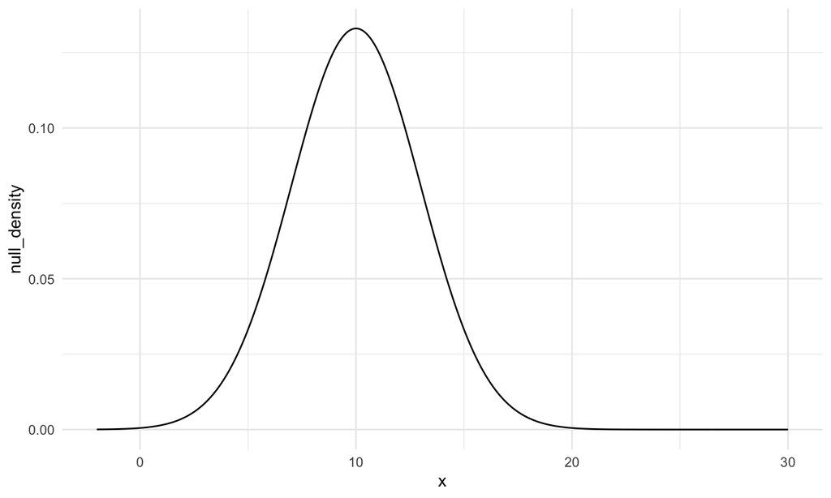

## Critical value

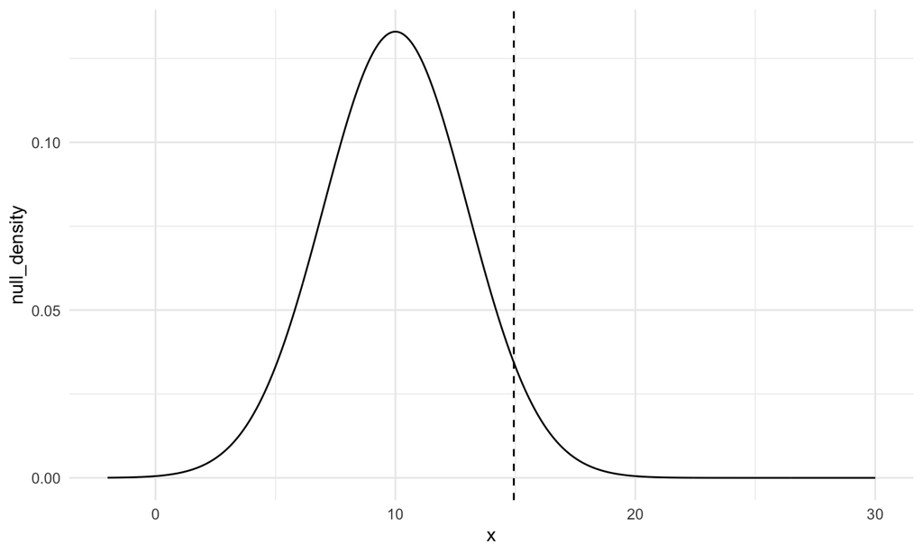

## Type I error (\(\alpha\))

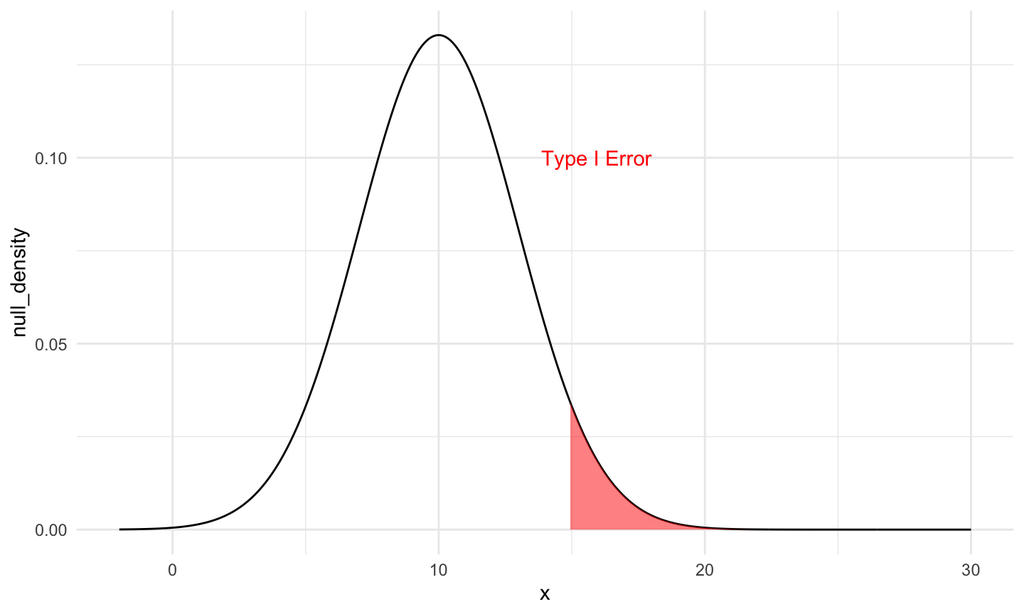

## Confidence

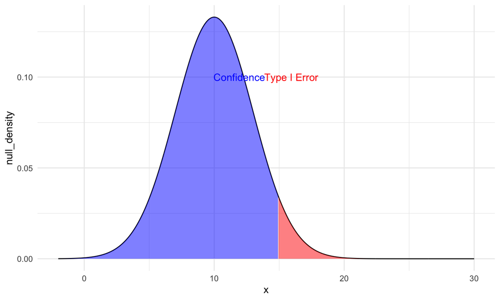

## The alternative distribution

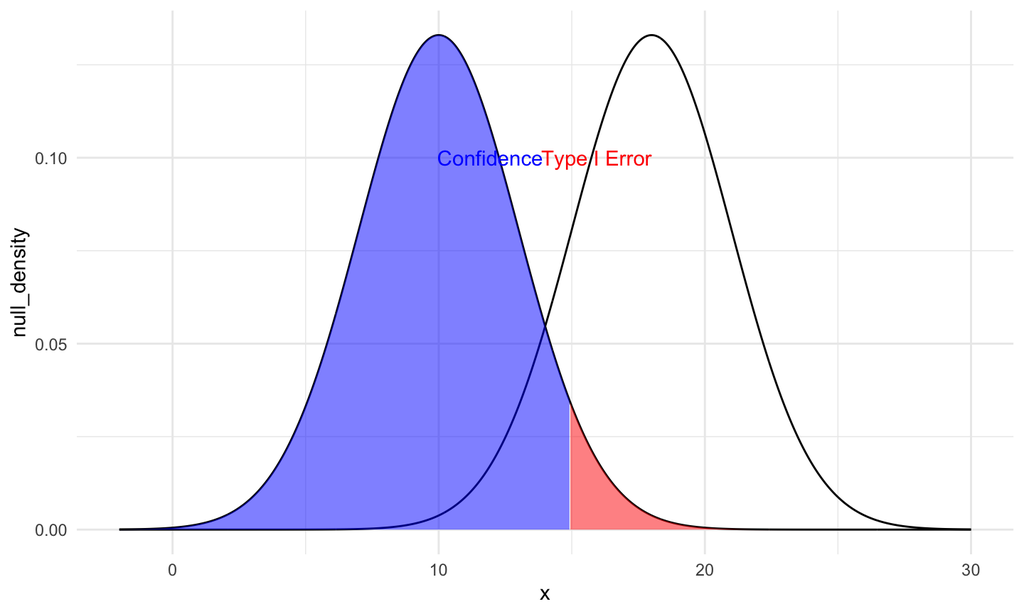

## Type II error

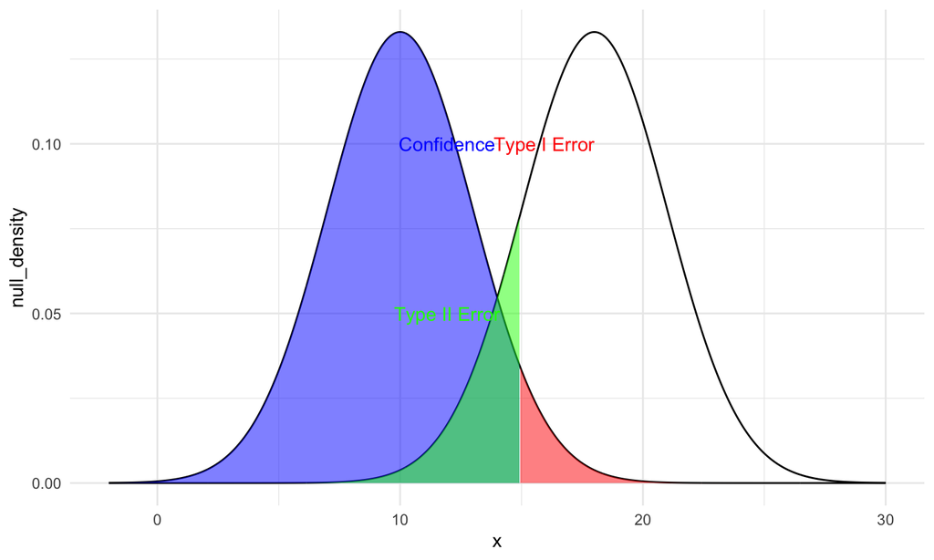

## Power is a good thing!

- Power is the probability of rejecting \(H_0\) when \(H_0\) is false.
- It is the probability of finding an effect when there is really an effect there to be found.
- Grating agencies typically want to see power of at least 0.8 when you design and propose experiments.

## Power and sample size \(n\)

- Power increases as sample size increases.
- This is because the standard error of the mean decreases as sample size increases.

## Power increases as sample size increases

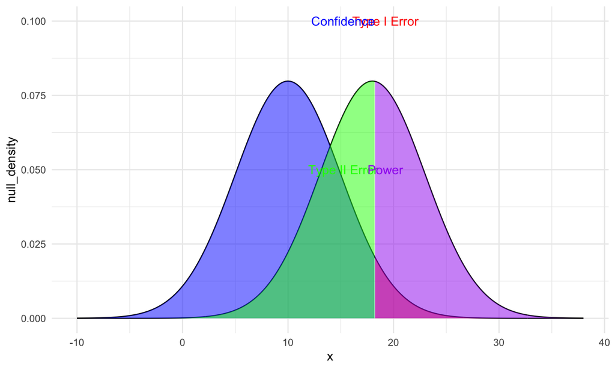

## Power increases as sample size increases

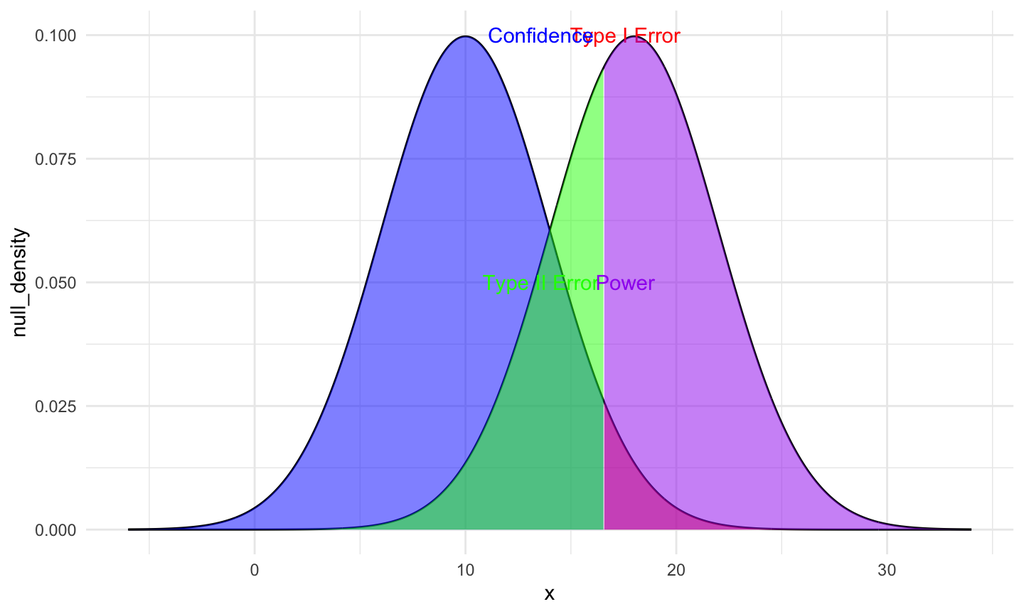

## Power increases as the effect size increases

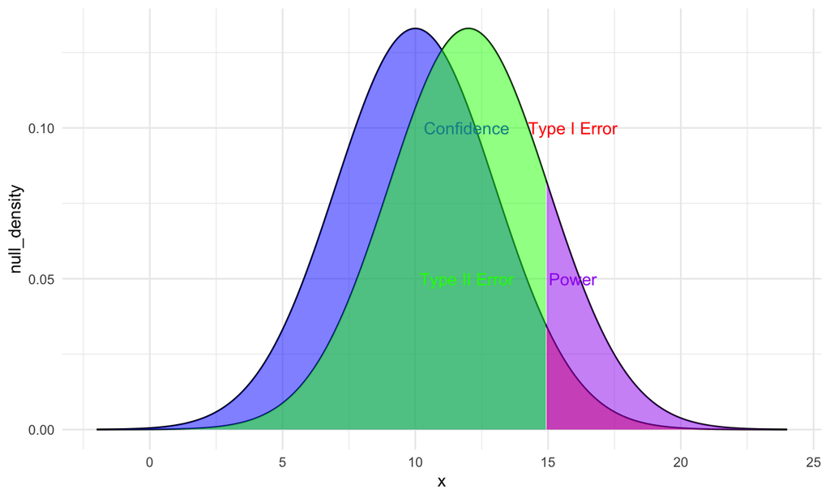

## Power increases as the effect size increases

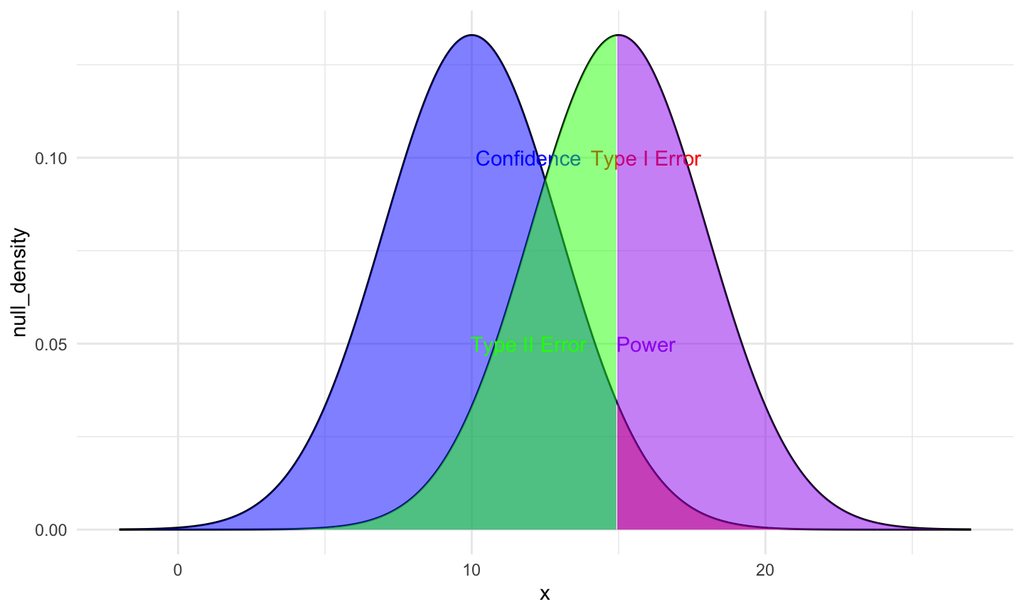

## Question

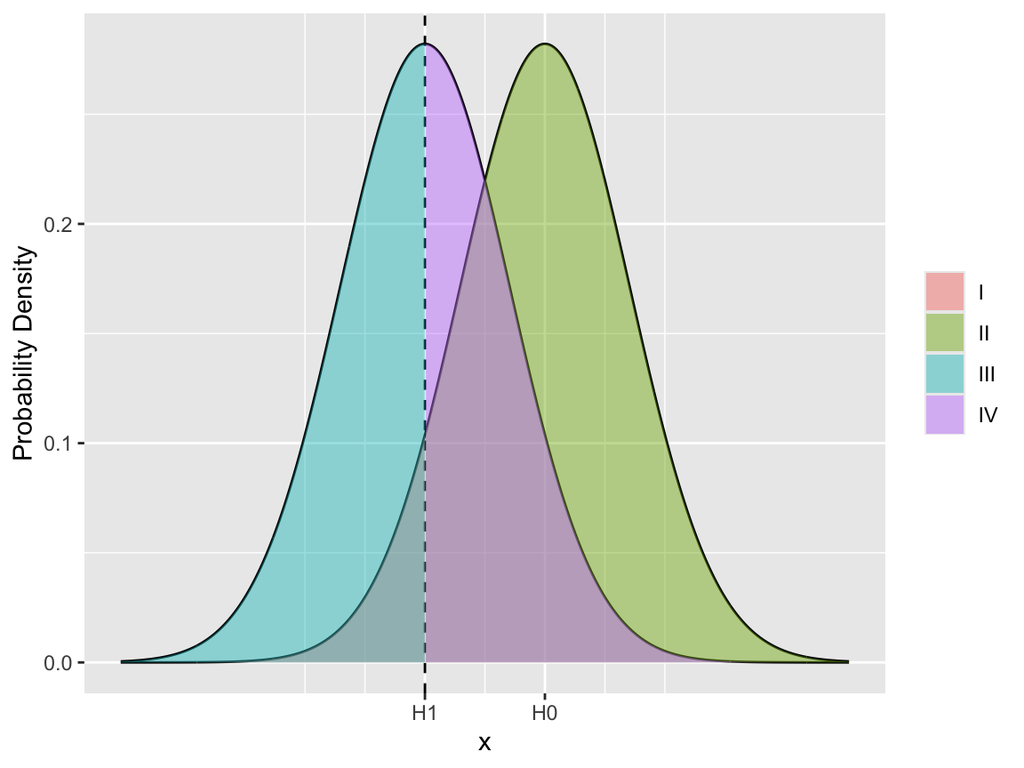

- What quantity does region I in the above plot correspond to?
- What quantity does region II in the above plot correspond to?
- What quantity does region III in the above plot correspond to?
- What quantity does region IV in the above plot correspond to?
- What is the numeric value (to two decimal places) of the power in this example?
- Assuming a type I error rate of 0.05, what is the numeric value (to two decimal places) of confidence of this example?
- Assuming that the illustrated distributions correspond to the distribution of sample means, will increasing the sample size increase the distance between the mean of H1 and H0 distributions?